# TRABAJO 2 TEORIA DE LA DECISION

# MÉTODO ELECTREE

```r
p <- multicriterio.crea.matrizdecision(
    c(100, 15,
      200, 25,
      100, 20,
      200, 30),numalternativas = 4,numcriterios = 2)
p
```

```
##     C1 C2
## a1 100 15
## a2 200 25
## a3 100 20
## a4 200 30
```

```r
W <- c(0.3, 0.7)
alpha <- 0.7
d <- c(Inf,Inf,Inf,Inf,Inf)

sol_electree <- multicriterio.metodoELECTRE_I(p,
                    pesos.criterios = W,
                    nivel.concordancia.minimo.alpha = alpha,
                    no.se.compensan = d,
                    que.alternativas = TRUE)
sol_electree
```

```
## $datos
##                    C1   C2
## a1              100.0 15.0
## a2              200.0 25.0
## a3              100.0 20.0
## a4              200.0 30.0
## pesos.criterios   0.3  0.7
## no.se.compensan   Inf  Inf
##
## $alpha
## [1] 0.7
##
## $Imas
## , , C1
##
##       a1    a2    a3    a4
## a1 FALSE FALSE FALSE FALSE
## a2  TRUE FALSE  TRUE FALSE
## a3 FALSE FALSE FALSE FALSE
## a4  TRUE FALSE  TRUE FALSE
##
## , , C2
##
##       a1    a2    a3    a4
## a1 FALSE FALSE FALSE FALSE
## a2  TRUE FALSE  TRUE FALSE
## a3  TRUE FALSE FALSE FALSE
## a4  TRUE  TRUE  TRUE FALSE
##
##
## $Iigual
## , , C1
##
##       a1    a2    a3    a4
## a1  TRUE FALSE  TRUE FALSE
## a2 FALSE  TRUE FALSE  TRUE
## a3  TRUE FALSE  TRUE FALSE
## a4 FALSE  TRUE FALSE  TRUE
##
## , , C2
```

[output cut: 49 more lines]

```
## a1 TRUE TRUE TRUE TRUE
## a2 TRUE TRUE TRUE TRUE
## a3 TRUE TRUE TRUE TRUE
## a4 TRUE TRUE TRUE TRUE
##
## $relacion.dominante
##       a1    a2    a3    a4
## a1 FALSE FALSE FALSE FALSE
## a2  TRUE FALSE  TRUE FALSE
## a3  TRUE FALSE FALSE FALSE
## a4  TRUE  TRUE  TRUE FALSE
##
## $nucleo_aprox
## a4
##  4
```

```r
qgraph::qgraph(sol_electree$relacion.dominante) #representación
```

[output not shown]

# MÉTODO PROMETHEE

```r
sol_promethee <- multicriterio.metodo.promethee_i(p,
    pesos.criterios = W,
    tab.fpref = matrix(c(1,0,0,0,
                         1,0,0,0,
                         1,0,0,0,
                         1,0,0,0), ncol = 4,byrow = T))
sol_promethee
```

```
## $tabla.indices
##     a1  a2 a3 a4
## a1 0.0 0.0  0  0
## a2 1.0 0.0  1  0
## a3 0.7 0.0  0  0
## a4 1.0 0.7  1  0
##
## $vflujos.ent
##  a1  a2  a3  a4
## 0.0 2.0 0.7 2.7
##
## $vflujos.sal
##  a1  a2  a3  a4
## 2.7 0.7 2.0 0.0
##
## $tablarelacionsupera
##     a1  a2  a3  a4
## a1 0.5 0.0 0.0 0.0
## a2 1.0 0.5 1.0 0.0
## a3 1.0 0.0 0.5 0.0
## a4 1.0 1.0 1.0 0.5
```

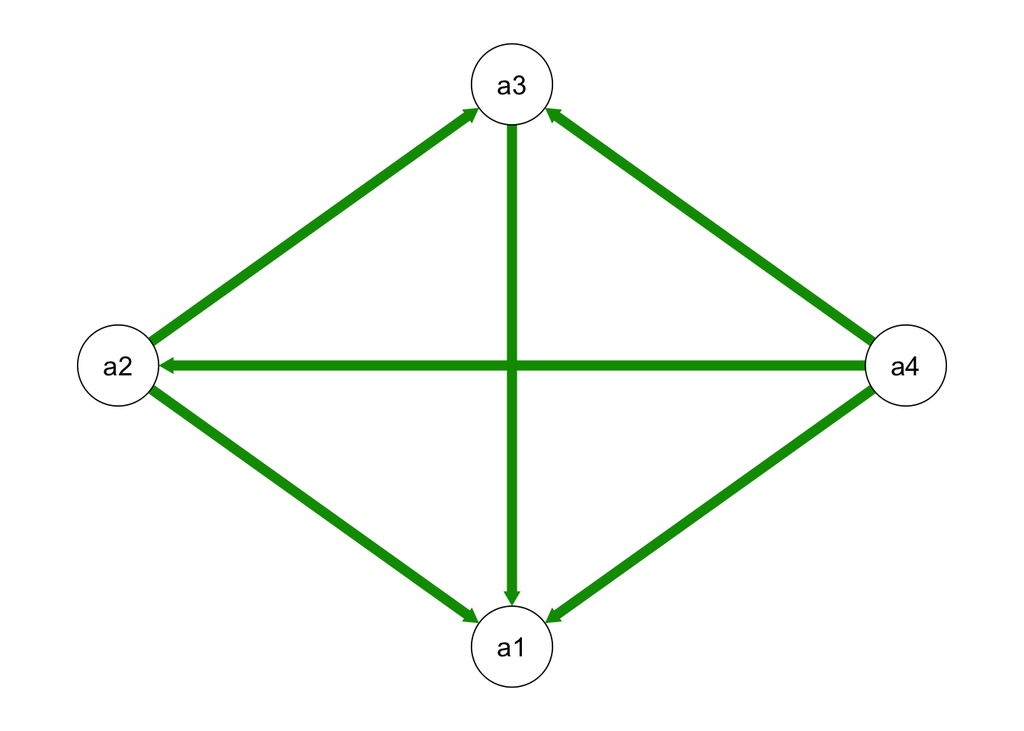

```r
qgraph::qgraph(sol_promethee$tablarelacionsupera)
```

```r
sol_promethee2 <- multicriterio.metodo.promethee_ii(p,
    pesos.criterios = W,
    tab.fpref = matrix(c(1,0,0,0,
                         1,0,0,0,
                         1,0,0,0,
                         1,0,0,0),ncol = 4,byrow = T))
sol_promethee2
```

```
## $tabla.indices
##     a1  a2 a3 a4
## a1 0.0 0.0  0  0
## a2 1.0 0.0  1  0
## a3 0.7 0.0  0  0
## a4 1.0 0.7  1  0
##
## $vflujos.netos
##   a1   a2   a3   a4
## -2.7  1.3 -1.3  2.7
##
## $tablarelacionsupera
##     a1  a2  a3  a4
## a1 0.5 0.0 0.0 0.0
## a2 1.0 0.5 1.0 0.0
## a3 1.0 0.0 0.5 0.0
## a4 1.0 1.0 1.0 0.5
```

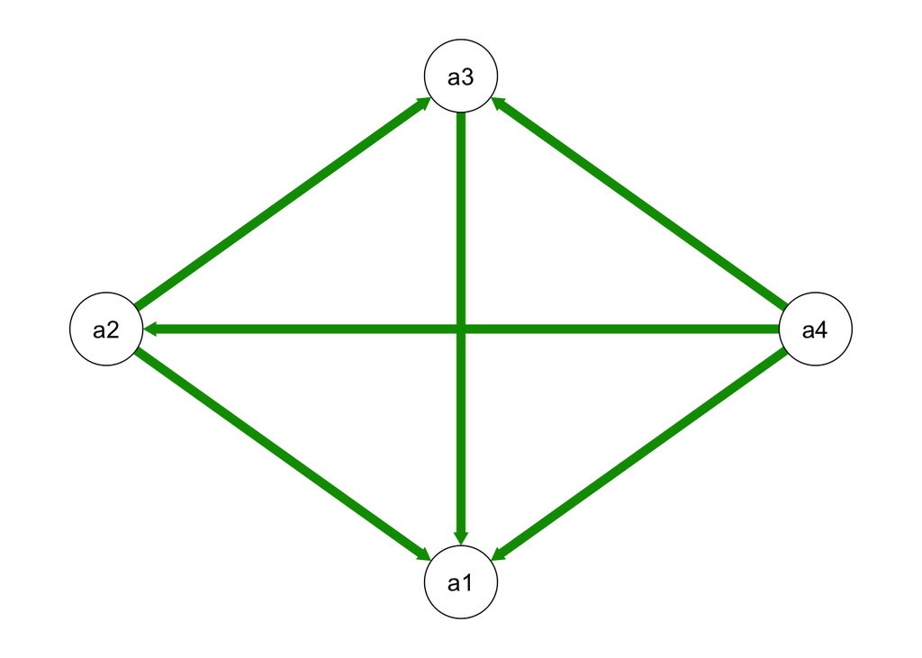

```r
qgraph::qgraph(sol_promethee2$tablarelacionsupera)
```

```r
order(sol_promethee2$vflujos.netos,decreasing = T)
```

```
## [1] 4 2 3 1
```

Con esta ordenación vemos que la mejor alternativa es a4, mientras que la peor es a1. Al igual que antes, en el gráfico vemos que a4 es la que más domina a las otras, mientras que a1 no domina a ninguna otra alternativa, por tanto es la peor.

*MÉTODO PROMETHEE MEDIAS*

```r
tab.Pthee.i_med <- multicriterio.metodo.promethee_i_med(p,W,
                                                        tab.fpref=matrix(c(1,0,0,0,
                                                                           1,0,0,0,
                                                                           1,0,0,0,
                                                                           1,0,0,0), ncol = 4,byrow = T))
tab.Pthee.i_med
```

```
## $tabla.indices
##     a1  a2 a3 a4
## a1 0.0 0.0  0  0
## a2 1.0 0.0  1  0
## a3 0.7 0.0  0  0
## a4 1.0 0.7  1  0
##
## $vflujos.ent
##        a1        a2        a3        a4
## 0.0000000 0.6666667 0.2333333 0.9000000
##
## $vflujos.sal
##        a1        a2        a3        a4
## 0.9000000 0.2333333 0.6666667 0.0000000
##
## $tablarelacionsupera
##    a1 a2 a3 a4
## a1  0  0  0  0
## a2  1  0  1  0
## a3  1  0  0  0
## a4  1  1  1  0
```

```r
qgraph::qgraph(tab.Pthee.i_med$tablarelacionsupera)
```

[output not shown]

```r
tab.Pthee.ii_med <- multicriterio.metodo.promethee_ii_med(p,W,
                                                          tab.fpref=matrix(c(1,0,0,0,
                                                                               1,0,0,0,
                                                                               1,0,0,0,
                                                                               1,0,0,0), ncol = 4,byrow = T))
tab.Pthee.ii_med
```

```
## $tabla.indices
##     a1  a2 a3 a4
## a1 0.0 0.0  0  0
## a2 1.0 0.0  1  0
## a3 0.7 0.0  0  0
## a4 1.0 0.7  1  0
##
## $vflujos.netos
##         a1         a2         a3         a4
## -0.9000000  0.4333333 -0.4333333  0.9000000
##
## $tablarelacionsupera
##    a1 a2 a3 a4
## a1  0  0  0  0
## a2  1  0  1  0
## a3  1  0  0  0
## a4  1  1  1  0
```

```r
qgraph::qgraph(tab.Pthee.ii_med$tablarelacionsupera)
```

[output not shown]

```r
order(tab.Pthee.ii_med$vflujos.netos,decreasing = T)
```

```
## [1] 4 2 3 1
```

# Método Axiomático de Arrow y Raymond

```r
sejarrow <- multicriterio.metodoaxiomatico.ArrowRaymond(p)
sejarrow
```

```
## $pasos
## $pasos[[1]]
## $pasos[[1]]$Mclasificacion
##     a1  a2  a3  a4
## a1  NA 0.0 0.5 0.0
## a2 2.0  NA 2.0 0.5
## a3 1.5 0.0  NA 0.0
## a4 2.0 1.5 2.0  NA
##
## $pasos[[1]]$max.filas
##  a1  a2  a3  a4
## 0.5 2.0 1.5 2.0
##
## $pasos[[1]]$indices.ordenados
## [1] 1 3 2 4
##
## $pasos[[1]]$alternativa.sale
## [1] "a1"
##
##
## $pasos[[2]]
## $pasos[[2]]$Mclasificacion
##     a2 a3  a4
## a2  NA  2 0.5
## a3 0.0 NA 0.0
## a4 1.5  2  NA
##
## $pasos[[2]]$max.filas
## a2 a3 a4
##  2  0  2
##
## $pasos[[2]]$indices.ordenados
## [1] 2 1 3
##
## $pasos[[2]]$alternativa.sale
## [1] "a3"
##
##
## $pasos[[3]]
## $pasos[[3]]$Mclasificacion
##     a2  a4
## a2  NA 0.5
## a4 1.5  NA
##
## $pasos[[3]]$max.filas
##  a2  a4
## 0.5 1.5
##
## $pasos[[3]]$indices.ordenados
## [1] 1 2
##
## $pasos[[3]]$alternativa.sale
## [1] "a2"
##
##
##
## $alternativasordenadas
## [1] "a4" "a2" "a3" "a1"
```

```r
sejarrow$alternativasordenadas
```

```
## [1] "a4" "a2" "a3" "a1"
```

*Análisis paramétrico o de sensibilidad aplicación Método axiomático de Arrow y Raymond*

```r
intalpha = seq(0,0.5,0.1)
sol = vector("list",length(intalpha))
for (i in 1:length(intalpha)) {
    p_i = p
    p_i[1,] = p_i[1,] * intalpha[i]
    sej_i = multicriterio.metodoaxiomatico.ArrowRaymond(p_i)
    sol[[i]] = sej_i$alternativasordenadas}
sol
```

```
## [[1]]
## [1] "a4" "a2" "a3" "a1"
##
## [[2]]
## [1] "a4" "a2" "a3" "a1"
##
## [[3]]
## [1] "a4" "a2" "a3" "a1"
##
## [[4]]
## [1] "a4" "a2" "a3" "a1"
##
## [[5]]
## [1] "a4" "a2" "a3" "a1"
##
## [[6]]
## [1] "a4" "a2" "a3" "a1"
```

```r
posiciones_a4 = rep(NA,length(intalpha))
for (i in 1:length(intalpha)) {
    posiciones_a4[i] = which(sol[[i]]=="a4")}
posiciones_a4
```

```
## [1] 1 1 1 1 1 1
```

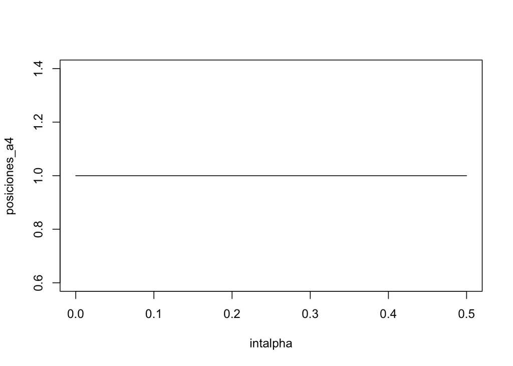

```r
plot(intalpha,posiciones_a4,type= "l") #Representación gráfica de estos cambios
```

Se puede observar que la alternativa 4 ha estado siempre en la primera posición